# Tutorial on Bayesian Graphical Modeling

# Plotting the Network Parameters

## Estimation: What is the strength and direction of the edge?

Once we’ve established which edges have credible evidence for inclusion, we can inspect the **strength and direction** of those connections. But which ones should we show?

In Bayesian model averaging, not all edges have convincing evidence. Some might be weak or ambiguous. By default, `easybgm` visualizes the **median probability model**, the network consisting of all edges with a posterior inclusion probability > 0.5 (or equivalently, Bayes Factor > 1). You can adjust this threshold using the `exc_prob` argument:

```r
plot_network(fit, exc_prob = 0.5)
```

[figure not shown]

**Exercise**

1. What conclusions can you draw from the estimated network?
2. This network is based on the **median probability model**. What does that mean, and how does it relate to the inclusion Bayes factors from the previous part?
3. Run `plot_network()` with and without the `exc_prob` argument. Does changing the `exc_prob` value influence which edges are shown?

**Solution (R)**

```r
# Default plot (median probability model: exc_prob = 0.5)
plot_network(fit)

# Stricter threshold: exc_prob = 0.8
plot_network(fit, exc_prob = 0.8)
```

**Solution (JASP)**

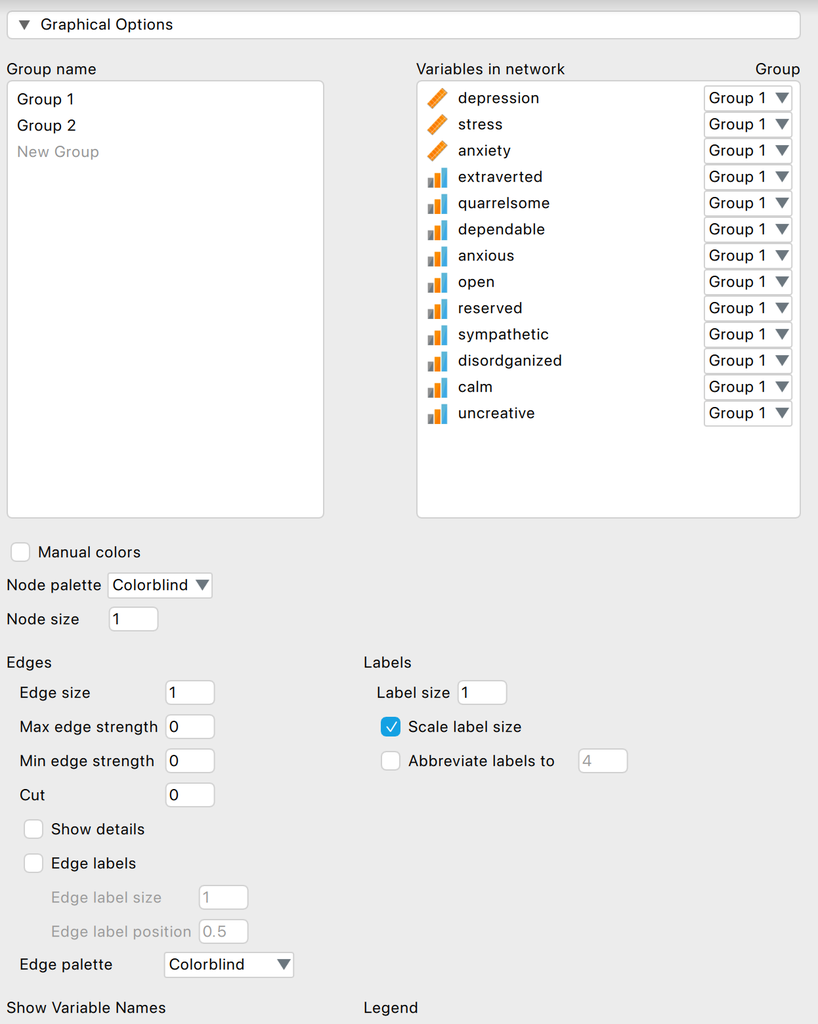

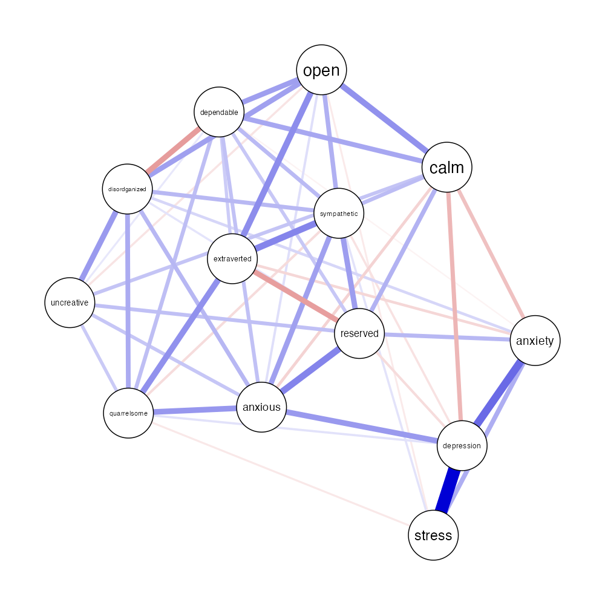

- JASP also shows the **median probability model** by default.
- You can adjust the **edge inclusion threshold** in the analysis options.
- Raising the threshold makes the network sparser, lowering it makes it denser.

Under the hood, `easybgm` uses `qgraph`, meaning you can pass any of its arguments to fully control the layout and style. For example, grouping nodes or setting colors.

## Parameter Uncertainty: HDI Intervals

The network plot shows **posterior means**, but this hides uncertainty. A useful complement is the **posterior highest density interval (HDI)**, which shows how stable the estimates are

This plot highlights which posterior distributions are tightly concentrated, and which are uncertain, helping you interpret results more cautiously.

**Exercise**

Use `plot_parameterHDI()` to inspect parameter uncertainty.

✅ Which edges have narrow (precise) intervals?  
✅ Are any edge estimates near zero?

**Solution (R)**

```r
plot_parameterHDI(fit)
```

[figure not shown]

**Solution (JASP)**

JASP does not (yet) include a Highest Density Interval (HDI) plot for edge weights.

If you want to assess uncertainty in edge parameters, you’ll need to use R and the `plot_parameterHDI()` function from `easybgm`.

We expect this feature to be added in a future JASP release.

## Centrality

Centrality measures attempt to quantify how “important” a node is in the network. For example, how often it sits on the shortest path between other nodes (betweenness), or how connected it is overall (degree).

While popular, centrality metrics in psychological networks have been criticized for their instability and unclear interpretation, especially in small or highly interconnected networks.

The nice thing about the Bayesian approach is that it provides **credible intervals** for these centrality indices, giving you a sense of how uncertain these summaries are.

```r
plot_centrality(fit)
```

[figure not shown]

> ⚠️ *Caution:* Interpret centrality values as descriptive summaries — not causal influence or intervention targets. Use the credible intervals to judge whether centrality differences are meaningful.

# Understanding Priors in Bayesian Network Models

Priors allow us to encode assumptions about the network *before* seeing the data. These assumptions affect:

- **Structure**: Which edges we expect to be present
- **Parameters**: How strong or weak we expect connections to be

Some prior choices in `easybgm` to investigate:

| Prior Type | Argument Example | Interpretation |
| --- | --- | --- |
| Structure prior | `inclusion_probability = 0.1` | Sparse network (few edges) |
| Structure prior | `edge_prior = "Beta-Bernoulli"` | Allows data-driven sparsity tuning |
| Parameter prior | `interaction_scale = 0.25` | Shrinks estimates toward zero (informative) |
| Parameter prior | `interaction_scale = 2.5` | Allows large edge effects (diffuse, default) |

**Warning**

**Tip:** Try multiple priors and see how your conclusions change. This is a key part of Bayesian modeling.

# Prior Sensitivity Check

Let’s explore how different structure priors influence the analysis using two assumptions: one sparse and one dense.

```r
library("bgms")
```

**Exercise**

Estimate two networks on the ordinal variables (i.e., `data[, -c(1:3)]` in the dataset) using the `bgms` package:

- One with a **sparse prior**: `inclusion_probability = 0.1`
- One with a **dense prior**: `inclusion_probability = 0.7`

Then use `summary()` and `plot_edgeevidence()` to compare:

✅ Which edges are included or excluded?  
✅ Does the posterior structure probability change?

You can run the most recent version of the `bgms` software from `easybgm`, but to be on the save side, lets fix the `iter` and `update_method` options:

```r
fit <- easybgm(
  data = data[, -c(1:3)],
  type = "ordinal",
  package = "bgms",
  iter = 2e3, # bgms performs 4 chains (runs) with "iter" iterations in parallel
  update_method = "adaptive-metropolis", # default "nuts" takes long!
)
```

**Solution**

```r
library(easybgm)
library(bgms)

# Sparse prior model
fit_sparse <- easybgm(
  data = data[, -c(1:3)],
  type = "ordinal",
  package = "bgms",
  iter = 2e3,
  update_method = "adaptive-metropolis",
  inclusion_probability = 0.1,
  seed = 1234
)

# Dense prior model
fit_dense <- easybgm(
  data = data[, -c(1:3)],
  type = "ordinal",
  package = "bgms",
  iter = 2e3,
  update_method = "adaptive-metropolis",
  inclusion_probability = 0.7,
  seed = 1234
)
```

```r
summary(fit_sparse)
```

```r
AGGREGATED EDGE OVERVIEW
Number of edges with sufficient evidence for inclusion: 35
Number of edges with insufficient evidence: 7
Number of edges with sufficient evidence for exclusion: 3
Number of possible edges: 45

---
STRUCTURE OVERVIEW
Number of visited structures: 190
Number of possible structures: 3.518437e+13
Posterior probability of most likely structure: 0.103375
```

```r
summary(fit_dense)
```

```r
AGGREGATED EDGE OVERVIEW
Number of edges with sufficient evidence for inclusion: 35
Number of edges with insufficient evidence: 4
Number of edges with sufficient evidence for exclusion: 6
Number of possible edges: 45

---
STRUCTURE OVERVIEW
Number of visited structures: 149
Number of possible structures: 3.518437e+13
Posterior probability of most likely structure: 0.388625
```

```r
# Extract layout from one fit
layout_fixed <- fit_sparse$plot$layout

# Plot both networks using the same layout
par(mfrow = c(1, 2))

plot_edgeevidence(
  fit_sparse,
  legend = FALSE,
  layout = layout_fixed
)

plot_edgeevidence(
  fit_dense,
  legend = FALSE,
  layout = layout_fixed
)
```

[figure not shown]

**Solution (JASP)**

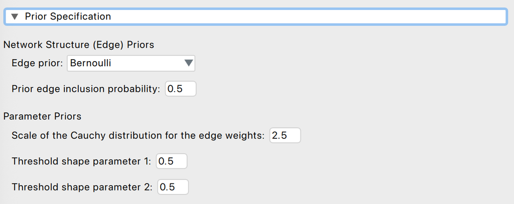

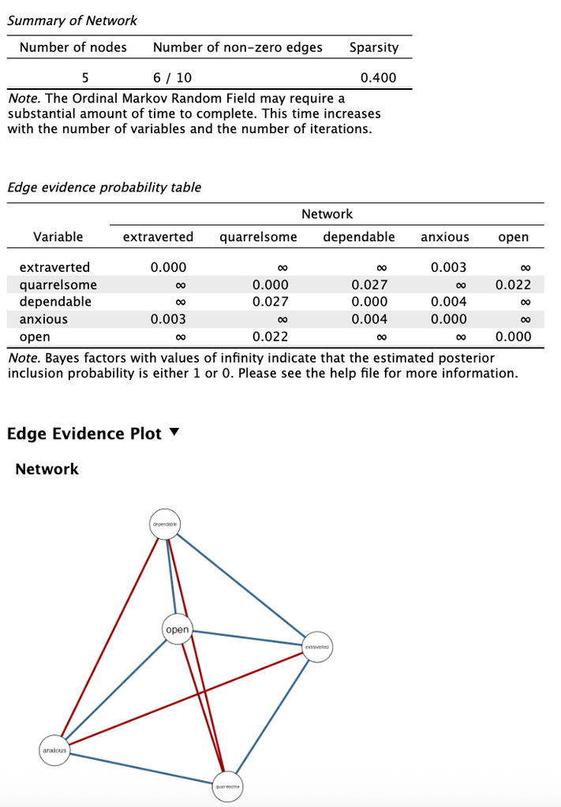

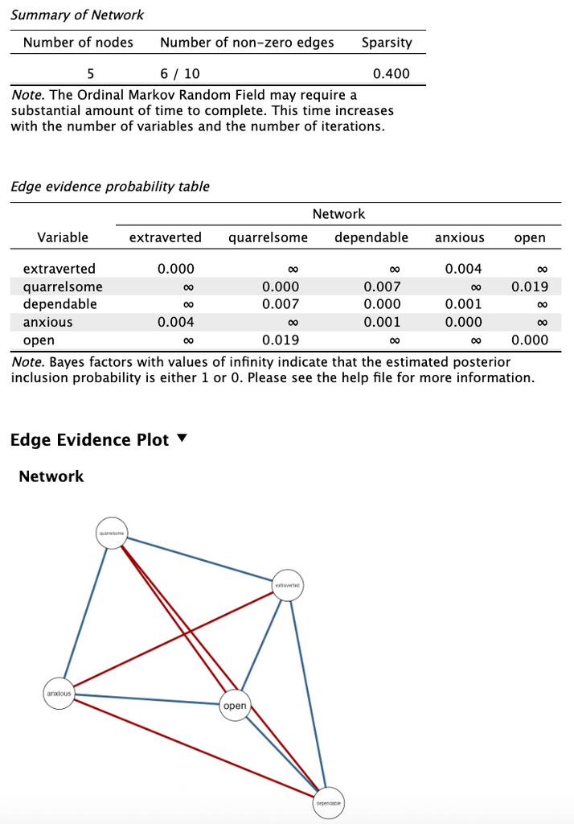

# What Should You Do in Practice?

- Start with defaults unless you have specific expectations.
- If theory or data suggest otherwise, adapt the prior accordingly.
- Always run at least one **sensitivity check**.
- Report your choices transparently.

# Recap of Part III

In this session you have seen the **practical benefits** of analyzing networks with a Bayesian approach, as outlined in the [tutorial paper](https://journals.sagepub.com/doi/10.1177/25152459231193334):

- *You can obtain evidence for both edge inclusion **and** exclusion*
- *You can quantify uncertainty about the network structure*
- *You can quantify the precision of estimated parameters*

To put this into practice, we walked through the full Bayesian workflow:

✅ Testing for edge inclusion using Bayes factors  
✅ Estimating edge parameters and visualizing uncertainty  
✅ Exploring the influence of priors on network conclusions  
✅ Doing all of this in both **R** and **JASP**

Whether you prefer writing code or working with a point-and-click interface, you now have the tools to perform Bayesian network analysis yourself.